# Hankowsky_HW5

## 7.28

```r
#read in data
neuron <- Sleuth3::ex0728

#looking at the dataframe and stats for each group
head(neuron)
```

```
##   Years Activity
## 1     0      5.0
## 2     0      6.0
## 3     0      7.5
## 4     0      9.0
## 5     0      9.5
## 6     0     11.0
```

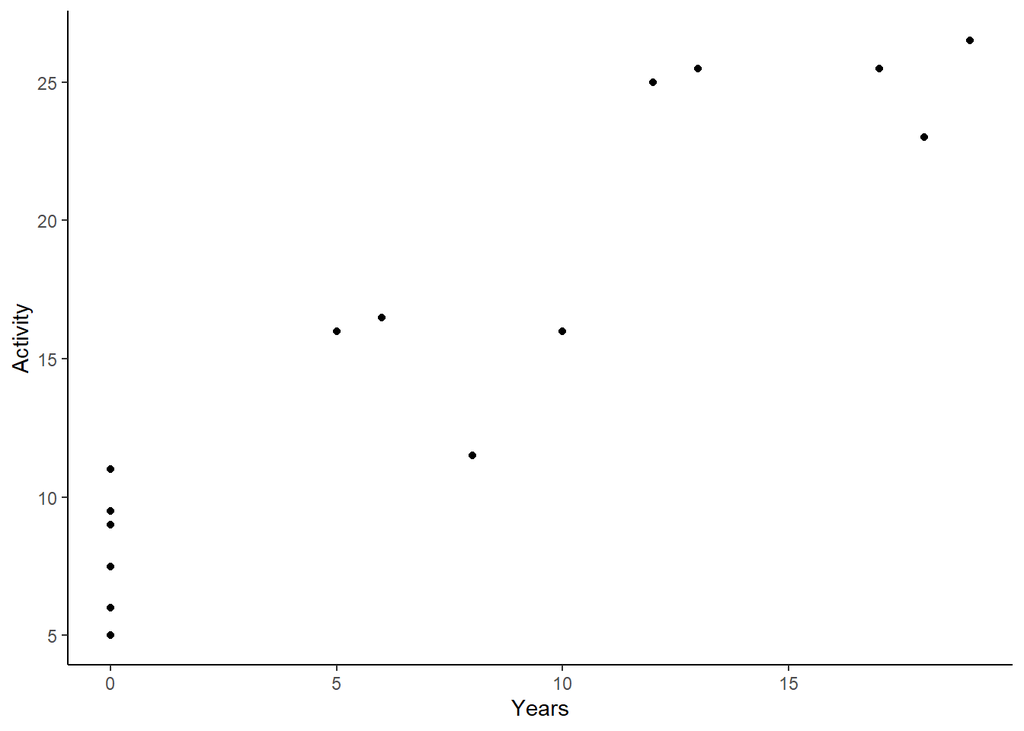

```r
#plot the activity level as a function of years
neuron %>%
  ggplot() +
  geom_point(aes( x= Years, y =  Activity)) +
  theme_classic()
```

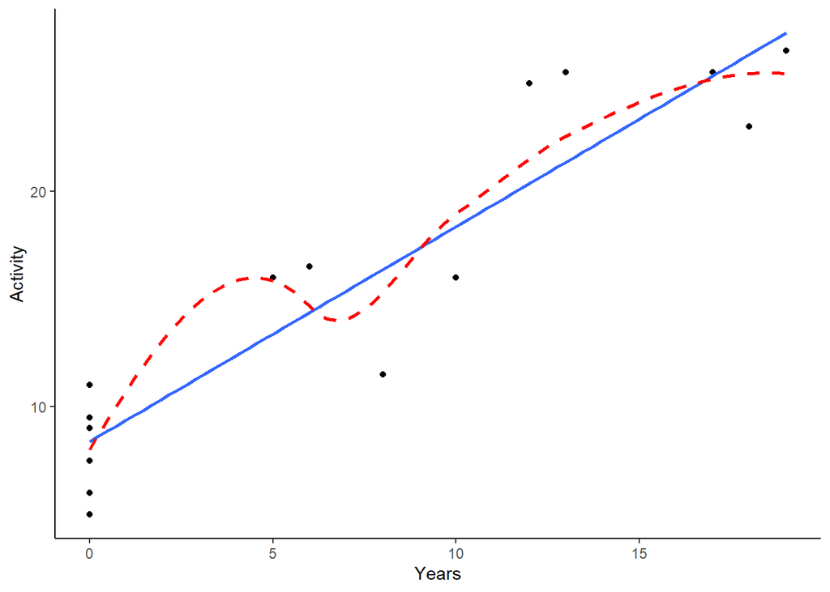

```r
#plot it again with the regression line and smooth
neuron %>%
  ggplot(aes( x= Years, y =  Activity)) +
  geom_point() +
  geom_smooth(method = "lm", se = F) +
  geom_smooth(method = stats::loess, se = FALSE, col = "red", lty = 2) +
  theme_classic()
```

```r
#run the regression
neuron_lm <- lm(Activity ~ Years, data = neuron)
summary(neuron_lm)
```

```
##
## Call:
## lm(formula = Activity ~ Years, data = neuron)
##
## Residuals:
##     Min      1Q  Median      3Q     Max
## -4.8644 -2.3730  0.1614  2.3713  4.6471
##
## Coefficients:
##             Estimate Std. Error t value Pr(>|t|)
## (Intercept)   8.3873     1.1149   7.523 4.35e-06 ***
## Years         0.9971     0.1110   8.980 6.18e-07 ***
## ---
## Signif. codes:  0 '***' 0.001 '**' 0.01 '*' 0.05 '.' 0.1 ' ' 1
##
## Residual standard error: 3.009 on 13 degrees of freedom
## Multiple R-squared:  0.8612, Adjusted R-squared:  0.8505
## F-statistic: 80.63 on 1 and 13 DF,  p-value: 6.178e-07
```

```r
anova(neuron_lm)
```

```
## Analysis of Variance Table
##
## Response: Activity
##           Df Sum Sq Mean Sq F value    Pr(>F)
## Years      1 730.21  730.21  80.633 6.178e-07 ***
## Residuals 13 117.73    9.06
## ---
## Signif. codes:  0 '***' 0.001 '**' 0.01 '*' 0.05 '.' 0.1 ' ' 1
```

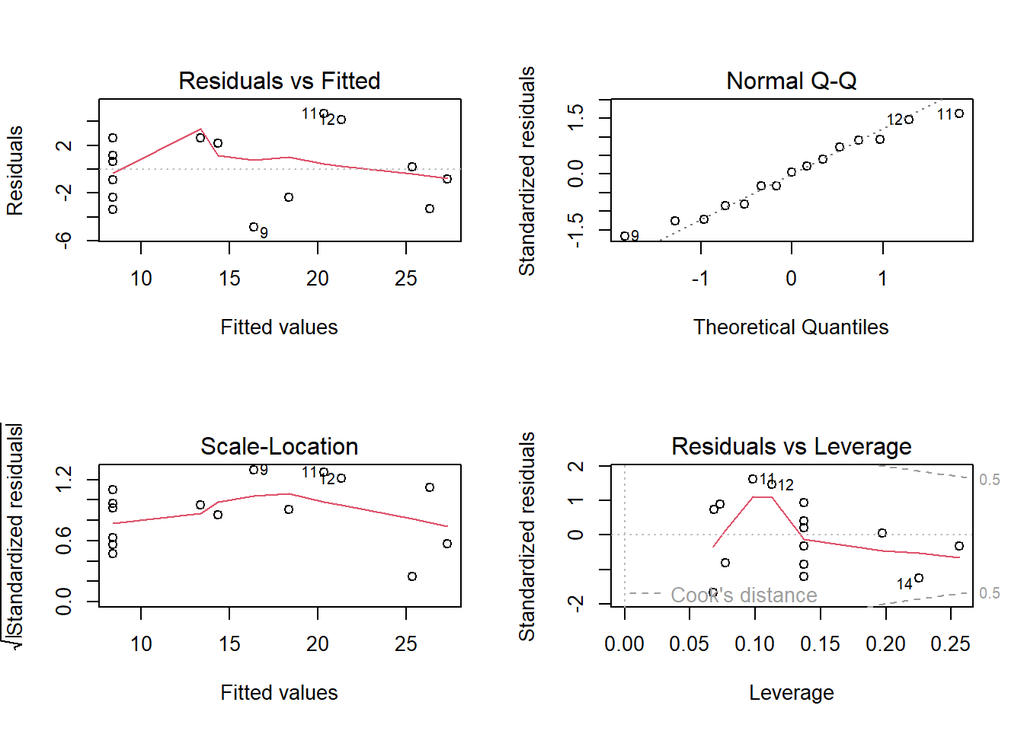

```r
#plot the diagnostics
par(mfrow=c(2,2))
plot(neuron_lm)
```

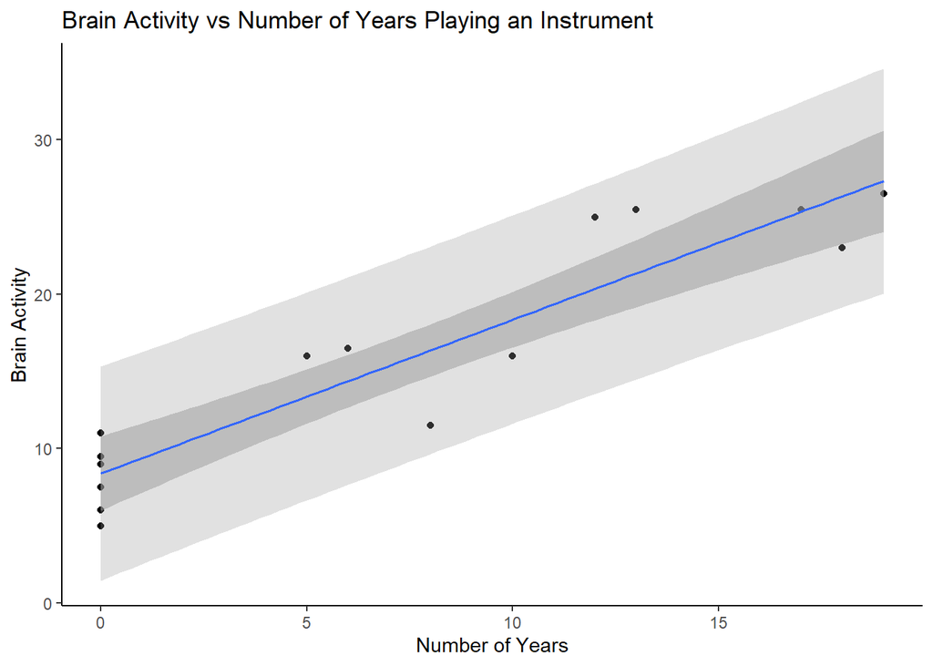

```r
#plot the presentation graphic
par(mfrow=c(1,1))

gf_point(Activity ~ Years, data = neuron) %>%
  gf_lm(interval = "prediction") %>%
  gf_lm(interval = "confidence", alpha = 0.5) +
  labs(title = "Brain Activity vs Number of Years Playing an Instrument",
       y = "Brain Activity", x = "Number of Years") +
  theme_classic()
```

These data provide overwhelming evidence that the amount of brain activity is associated with the number of years an individual has been playing the instrument ($\beta$ = 0.99, p-value < 0.001). There is overwhelming evidence that the neuron activity is different in the stringed musicians than the controls (two-sided p-value < 0.001; for a test that the intercept is zero). The diagnostic plots show some concern about the assumption of normality, however, OLS regression is robust to this violation and it is likely due to the small sample size (n = 15).

# Supplemental Problems

## 6.24(Sleuth 2nd Edition)

```r
#read in data
bearings <- Sleuth2::ex0621

#looking at the dataframe and stats for each group
head(bearings)
```

```
##    Time Compound
## 1  3.03        I
## 2  5.53        I
## 3  5.60        I
## 4  9.30        I
## 5  9.92        I
## 6 12.51        I
```

```r
favstats(Time ~ Compound, data = bearings)
```

```
##   Compound  min      Q1 median      Q3   max   mean       sd  n missing
## 1        I 3.03  6.5250 11.215 14.6450 16.84 10.693 4.819286 10       0
## 2       II 3.19  4.4850  4.680  6.5375 12.75  6.050 2.915045 10       0
## 3      III 3.46  5.9025  9.280 10.5800 13.41  8.636 3.290610 10       0
## 4       IV 5.88  6.9200  7.675  9.4975 25.46  9.798 5.806186 10       0
## 5        V 6.43 11.1800 14.585 17.9950 21.51 14.706 4.863365 10       0
```

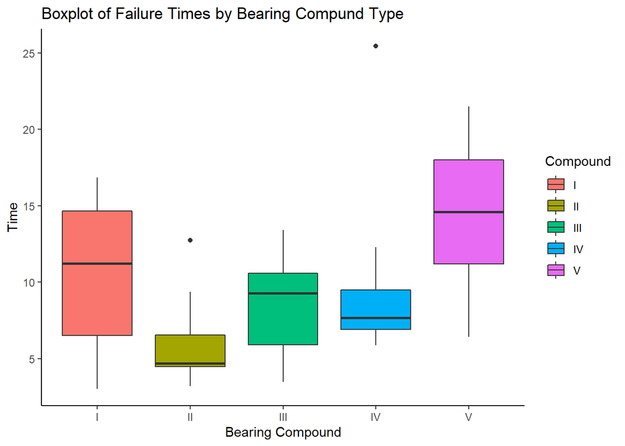

```r
#boxplot of time by compound
bearings %>%
  ggplot() +
  geom_boxplot(aes(x = Compound, y = Time, fill = Compound)) +
  labs(title = "Boxplot of Failure Times by Bearing Compund Type",
       x = "Bearing Compound", y = "Time") +
  theme_classic()
```

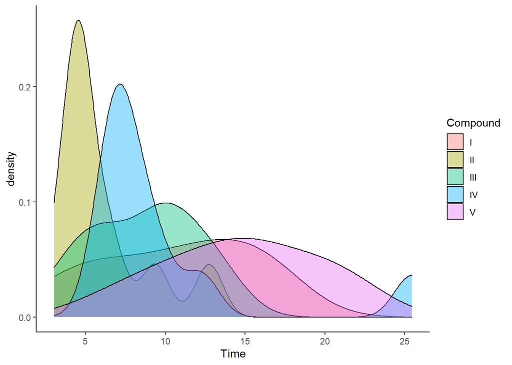

```r
#density plot of time by compound
bearings %>%
  ggplot() +
  geom_density(aes(x = Time, group = Compound, fill = Compound), alpha = 0.4) +
  theme_classic()
```

```r
#running the anova
bearing_aov <- aov(Time ~ Compound, data = bearings)
summary(bearing_aov)
```

```
##             Df Sum Sq Mean Sq F value  Pr(>F)
## Compound     4  401.3  100.32    5.02 0.00197 **
## Residuals   45  899.2   19.98
## ---
## Signif. codes:  0 '***' 0.001 '**' 0.01 '*' 0.05 '.' 0.1 ' ' 1
```

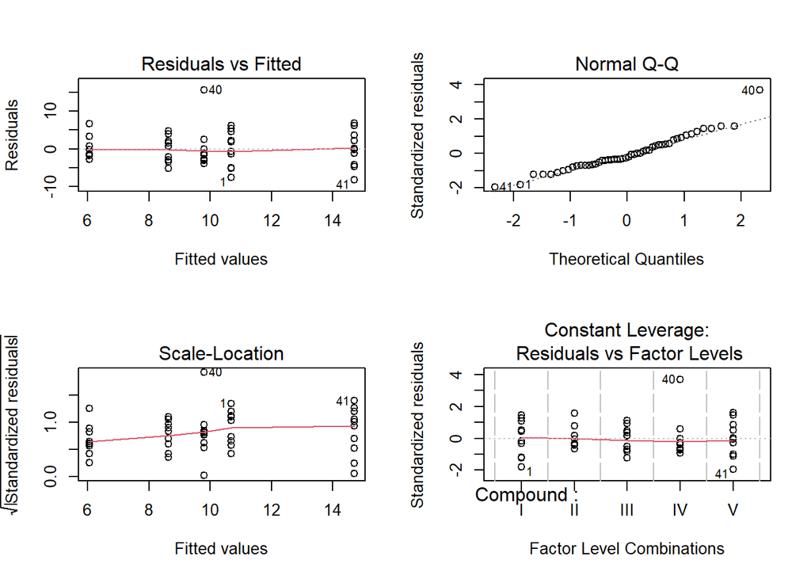

```r
par(mfrow=c(2,2))
plot(bearing_aov)
```

```r
#comparison of different groups
TukeyHSD(bearing_aov)
```

```
##   Tukey multiple comparisons of means
##     95% family-wise confidence level
##
## Fit: aov(formula = Time ~ Compound, data = bearings)
##
## $Compound
##              diff         lwr       upr     p adj
## II-I   -4.6430001 -10.3234907  1.037490 0.1567083
## III-I  -2.0570003  -7.7374909  3.623490 0.8406451
## IV-I   -0.8950002  -6.5754908  4.785490 0.9914058
## V-I     4.0129998  -1.6674907  9.693490 0.2791467
## III-II  2.5859998  -3.0944908  8.266490 0.6964484
## IV-II   3.7479999  -1.9324907  9.428490 0.3453895
## V-II    8.6559999   2.9755094 14.336491 0.0007521
## IV-III  1.1620001  -4.5184905  6.842491 0.9771836
## V-III   6.0700001   0.3895095 11.750491 0.0308937
## V-IV    4.9080000  -0.7724905 10.588491 0.1195580
```

## 7.27(Sleuth 2nd Edition)

```r
#read in data
nebulae <- Sleuth2::ex0727

#looking at the dataframe and stats for each group
head(nebulae)
```

```
##   Cluster Distance Velocity
## 1   Virgo     1.80      890
## 2 Pegasus     7.25     3810
## 3  Pisces     7.00     4638
## 4  Cancer     9.00     4820
## 5 Perseus    11.00     5230
## 6    Coma    13.80     7500
```

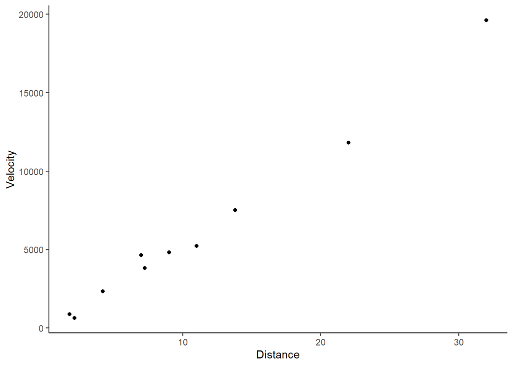

```r
#plot the distance as a function of velocity
nebulae %>%
  ggplot() +
  geom_point(aes( x= Distance, y =  Velocity)) +
  theme_classic()
```

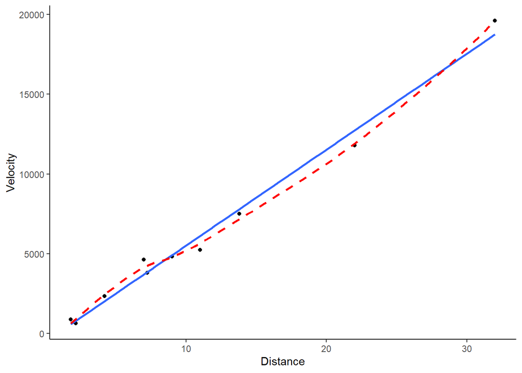

```r
#plot it again with the regression line and smooth
nebulae %>%
  ggplot(aes( x= Distance, y =  Velocity)) +
  geom_point() +
  geom_smooth(method = "lm", se = F) +
  geom_smooth(method = stats::loess, se = FALSE, col = "red", lty = 2) +
  theme_classic()
```

```r
#run the regression
nebulae_lm <- lm(Distance ~ Velocity, data = nebulae)
summary(nebulae_lm)
```

```
##
## Call:
## lm(formula = Distance ~ Velocity, data = nebulae)
##
## Residuals:
##      Min       1Q   Median       3Q      Max
## -1.57390 -0.61564  0.08178  0.43318  1.65894
##
## Coefficients:
##              Estimate Std. Error t value Pr(>|t|)
## (Intercept) 9.537e-01  5.251e-01   1.816    0.107
## Velocity    1.643e-03  6.401e-05  25.668 5.69e-09 ***
## ---
## Signif. codes:  0 '***' 0.001 '**' 0.01 '*' 0.05 '.' 0.1 ' ' 1
##
## Residual standard error: 1.104 on 8 degrees of freedom
## Multiple R-squared:  0.988,  Adjusted R-squared:  0.9865
## F-statistic: 658.9 on 1 and 8 DF,  p-value: 5.691e-09
```

```r
anova(nebulae_lm)
```

```
## Analysis of Variance Table
##
## Response: Distance
##           Df Sum Sq Mean Sq F value    Pr(>F)
## Velocity   1 803.35  803.35  658.87 5.691e-09 ***
## Residuals  8   9.75    1.22
## ---
## Signif. codes:  0 '***' 0.001 '**' 0.01 '*' 0.05 '.' 0.1 ' ' 1
```